# MidtermPractice

Lin Xiao

2025-10-25

## 1. Data

### 1.1 Data Description

Public transit ridership refers to the number of people who use public transportation services, such as buses, trains, subways, trams, and other forms of mass transit, to travel from one place to another. It is an important metric to assess the usage and popularity of public transportation systems in a given area. Understanding public transit ridership is crucial for transportation authorities, city planners, and policymakers because it can help inform decisions about funding, service improvements, and the overall effectiveness of a public transit system.

This dataset shows the Public Transit Raidership of the US from January 2000 to July 2023, including Date(Monthly) and one **time series** variable(TRANSIT).

```r
library(readr)
library(fpp2)
TRANSIT <- read_csv("TRANSIT.csv")
spec(TRANSIT)
Transit_Raw <- TRANSIT$TRANSIT
Transit_ts_ed <- ts(Transit_Raw, frequency = 12, start = c(2000,1))
head(Transit_ts_ed)
```

```
##         Jan    Feb    Mar    Apr    May    Jun
## 2000 724934 756536 843730 757458 818246 793911
```

```r
tail(Transit_ts_ed)
```

```
##         Feb    Mar    Apr    May    Jun    Jul
## 2023 512739 593360 560127 609180 572834 532206
```

## 2. Data overview

### 2.1 Data Plot

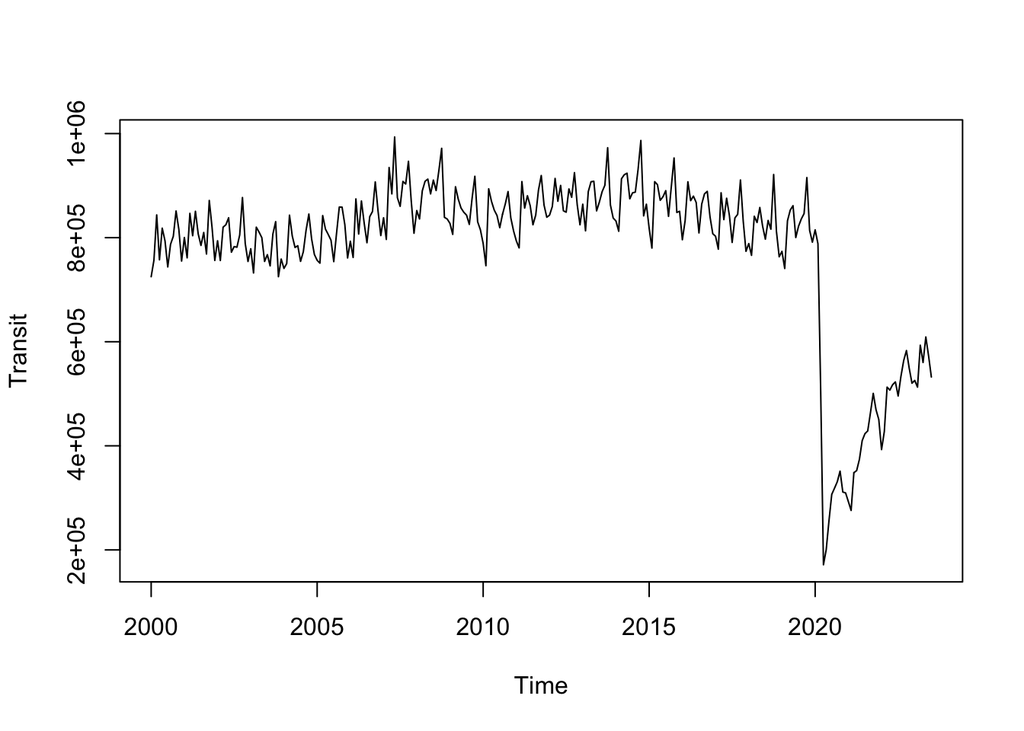

```r
plot(Transit_ts_ed, ylab= "Transit")
```

#### Summarry of Data Plot

- From 2000 to around 2019, the series shows moderate fluctuations with a fairly stable seasonal pattern — ridership levels generally remained within a consistent range, suggesting steady demand for public transit.
- Around early 2020, there is a sharp and dramatic decline in transit usage — a structural break most likely corresponding to the COVID-19 pandemic, which severely reduced mobility and public transportation usage. -After mid-2020, the series exhibits a gradual recovery trend, though ridership has not yet returned to pre-pandemic levels by the end of the observed period.
- The seasonal variation that was evident before 2020 appears to weaken after the drop, possibly indicating changes in travel behavior or commuting patterns post-pandemic.

#### Because the recent data differ from historical trends and show a sharp decline, data before 2021 were removed to keep only the more stable recent period..

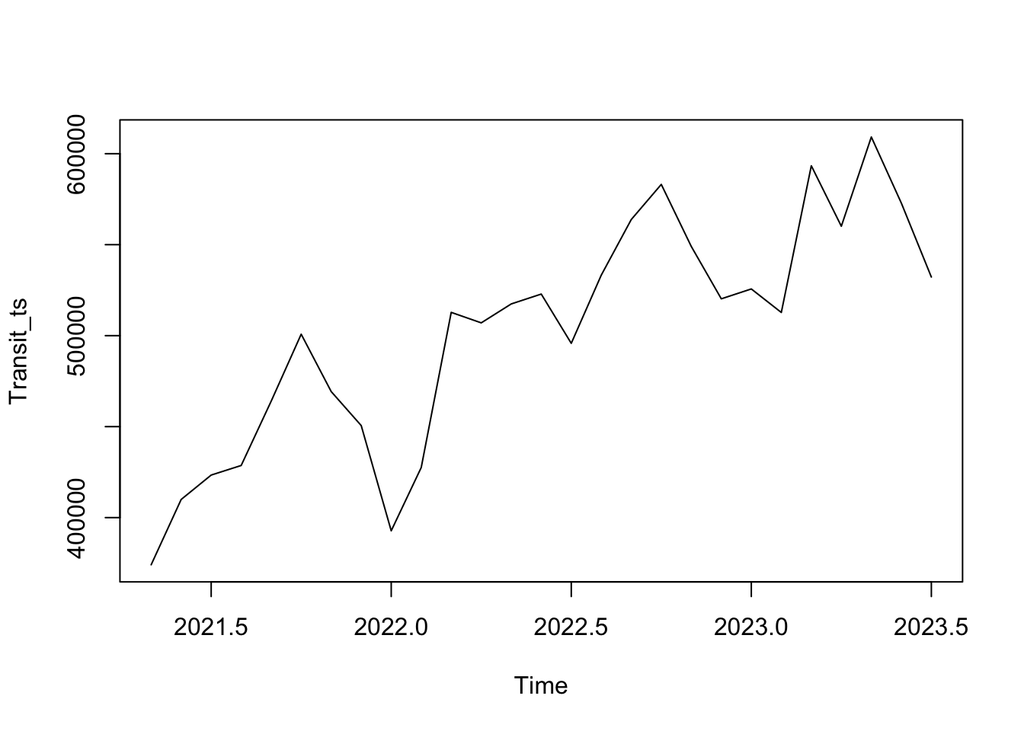

```r
Transit_ts <- window(Transit_ts_ed, start = c(2021, 5))

plot(Transit_ts)
```

### 2.2 Acf plot

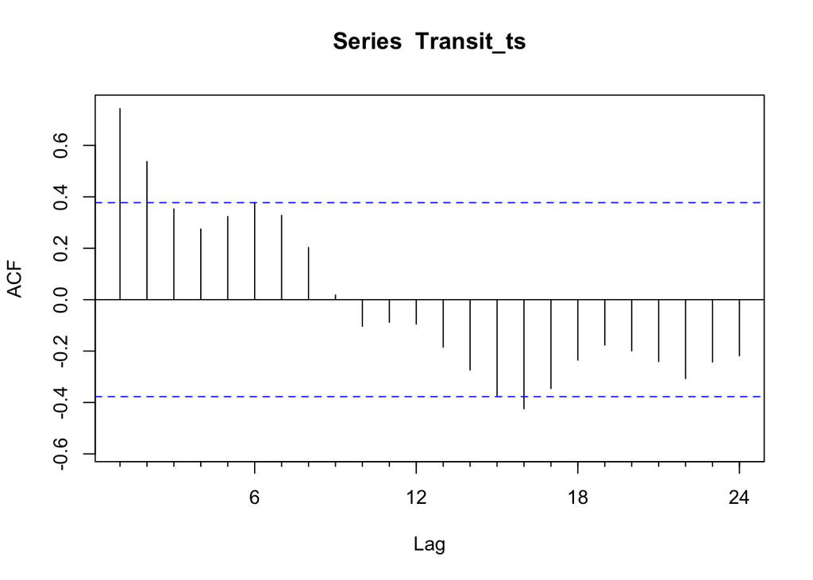

```r
Acf(Transit_ts)
```

> The ACF plot shows significant positive autocorrelation for the first few lags, which gradually decays to zero around lag 9 and turns slightly negative afterward. This pattern confirms that the series has short-term persistence (values close in time are correlated) and mild seasonality, consistent with the observed trend in the time-series plot. Hence, Acf plots indicate same result with time series plot the data contain a moderate upward trend and seasonal cycles.

### 2.3 Central Tendency

```r
# display summary statistics
summary(Transit_ts)
```

```
##    Min. 1st Qu.  Median    Mean 3rd Qu.    Max.
##  374081  457292  512795  501943  541132  609180
```

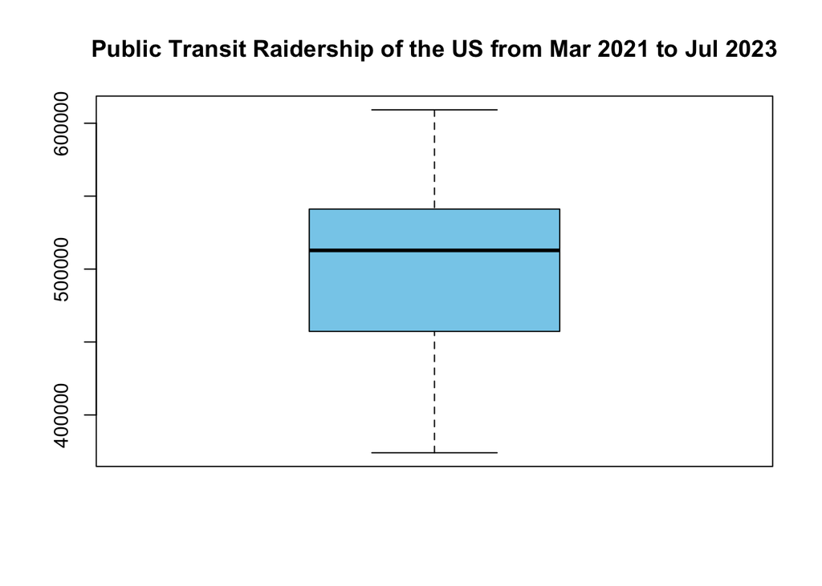

```r
boxplot(Transit_ts,
        main = "Public Transit Raidership of the US from Mar 2021 to Jul 2023",
        col = "skyblue")
```

#### Summary of Statistics and Box Plot Observations

The summary statistics are as follows:

| Statistic | Value |
| --- | --- |
| Minimum | 374081 |
| 1st Quartile (Q1) | 457292 |
| Median | 512795 |
| Mean | 501943 |
| 3rd Quartile (Q3) | 541132 |
| Maximum | 609180 |

## 3 Accuracy Evaluation Criteria

The forecasting accuracy of each model is evaluated using four common metrics: RMSE, MAE, MAPE, and MASE. Among them, **MASE (Mean Absolute Scaled Error)** is selected as the primary evaluation criterion, since it provides a scale-free comparison against the Naive benchmark and is less sensitive to extreme values. RMSE and MAE are included to assess error magnitude and robustness, while MAPE offers an intuitive percentage-based interpretation.

## 4. Models

### 3.1 Decomposition

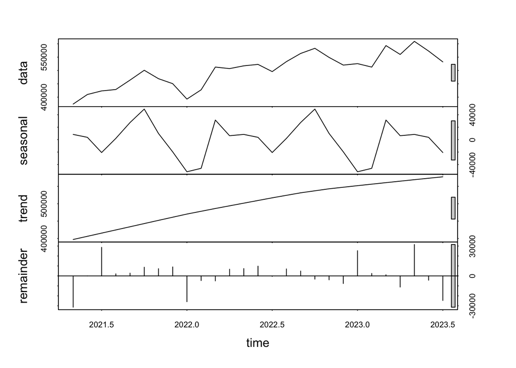

```r
transit_de <- stl(Transit_ts, s.window = "periodic")
plot(transit_de)
```

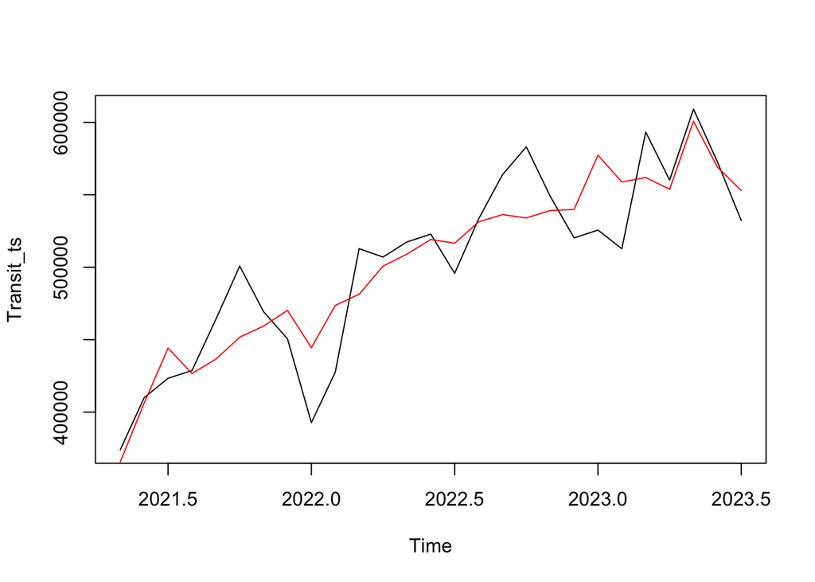

```r
transit_sajs <- seasadj(transit_de)
plot(Transit_ts)
lines(transit_sajs, col="red")
```

### 3.2 Naive Method

```r
naive_forecast <- naive(Transit_ts, 12)
```

#### 3.2.1 Residual Analysis

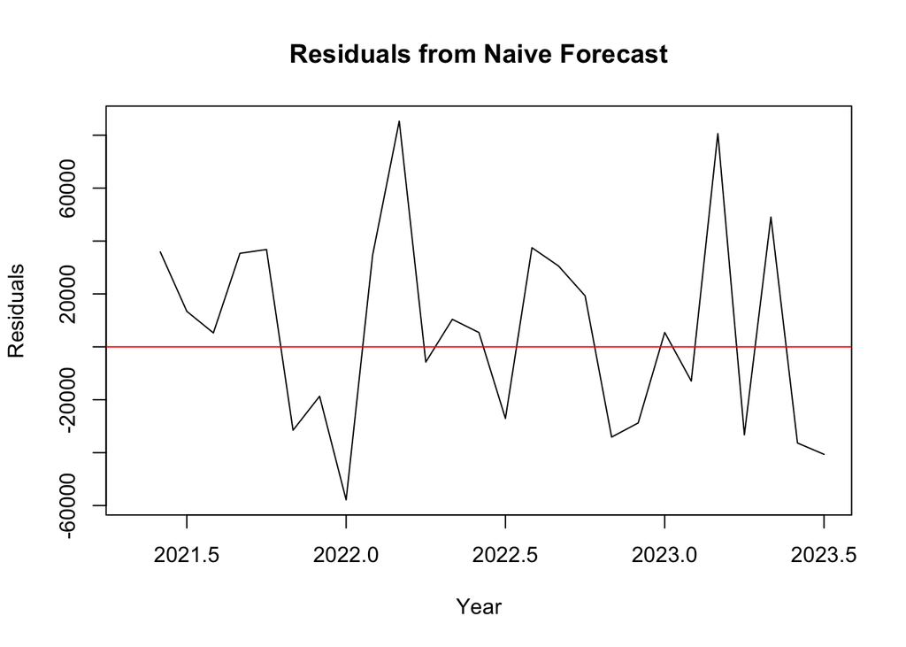

```r
naive_residual <- residuals(naive_forecast)
plot(naive_residual, main = "Residuals from Naive Forecast", ylab ="Residuals", xlab = "Year")
abline(h=0, col="red")
```

> The residuals are centered near zero,. These patterns indicate that the Naive model fails to fully account for the seasonal and trend components in this time series.

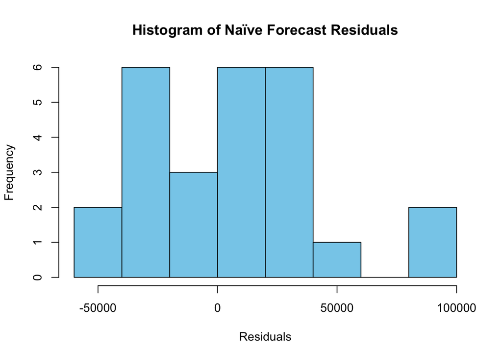

```r
hist(naive_residual, main = "Histogram of Naïve Forecast Residuals",
     xlab ="Residuals", col = "skyblue")
```

> Most residuals are near zero → good overall fit. A long right tail → model sometimes underestimates large ridership spikes.

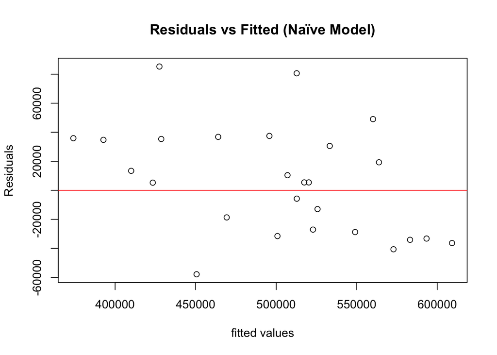

```r
plot(as.numeric(naive_forecast$fitted), as.numeric(naive_forecast$residuals),
     main = "Residuals vs Fitted (Naïve Model)",
     xlab = "fitted values", ylab = "Residuals")
abline(h = 0, col = "red")
```

> The residuals are generally centered around zero with no obvious pattern, suggesting that the Naïve model captures the basic structure of the data, though a few outliers and mild heteroscedasticity indicate limited accuracy during certain periods.

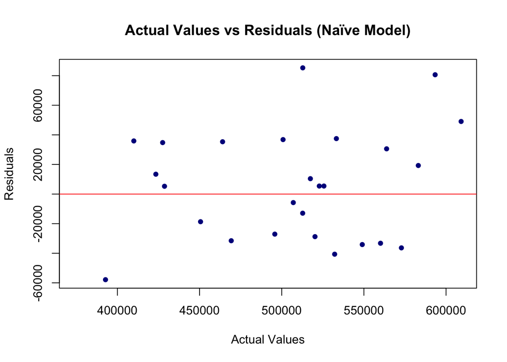

```r
plot(as.numeric(Transit_ts),as.numeric(naive_forecast$residuals),
     main = "Actual Values vs Residuals (Naïve Model)",
     xlab = "Actual Values", ylab = "Residuals",
     type = "p", pch = 19, col = "darkblue", cex= 0.8)
abline(h = 0, col = "red")
```

> Residuals are randomly distributed around zero, indicating no strong bias, though higher actual ridership values show larger residuals. This pattern suggests that while the Naïve model captures the overall direction of the data, it struggles to adapt to large fluctuations during peak periods.

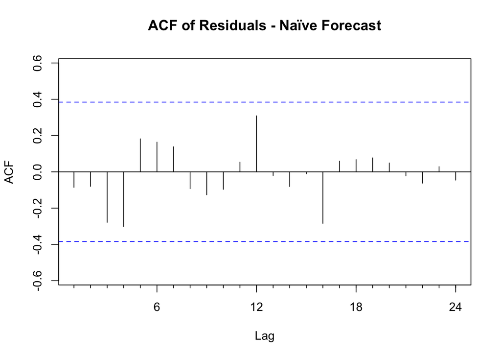

```r
Acf(naive_residual, main="ACF of Residuals - Naïve Forecast")
```

> All autocorrelation spikes fall within the blue confidence bounds, which means that the residuals are not significantly autocorrelated. This indicates that the residuals behave like white noise, suggesting that the Naïve model has captured most of the predictable structure in the time series.

#### 3.2.2 Naive Accuracy and forecast Plot

```r
accuracy(naive_forecast)
```

```
##                    ME     RMSE      MAE      MPE    MAPE      MASE        ACF1
## Training set 6081.731 37238.93 31228.35 1.076589 6.18174 0.3617862 -0.08569387
```

```r
naive_forecast
```

```
##          Point Forecast    Lo 80    Hi 80    Lo 95    Hi 95
## Aug 2023         532206 484482.4 579929.6 459219.0 605193.0
## Sep 2023         532206 464714.6 599697.4 428986.9 635425.1
## Oct 2023         532206 449546.3 614865.7 405788.9 658623.1
## Nov 2023         532206 436758.8 627653.2 386232.1 678179.9
## Dec 2023         532206 425492.8 638919.2 369002.2 695409.8
## Jan 2024         532206 415307.5 649104.5 353425.2 710986.8
## Feb 2024         532206 405941.2 658470.8 339100.7 725311.3
## Mar 2024         532206 397223.3 667188.7 325767.7 738644.3
## Apr 2024         532206 389035.2 675376.8 313245.1 751166.9
## May 2024         532206 381290.7 683121.3 301401.0 763011.0
## Jun 2024         532206 373924.7 690487.3 290135.7 774276.3
## Jul 2024         532206 366886.6 697525.4 279371.8 785040.2
```

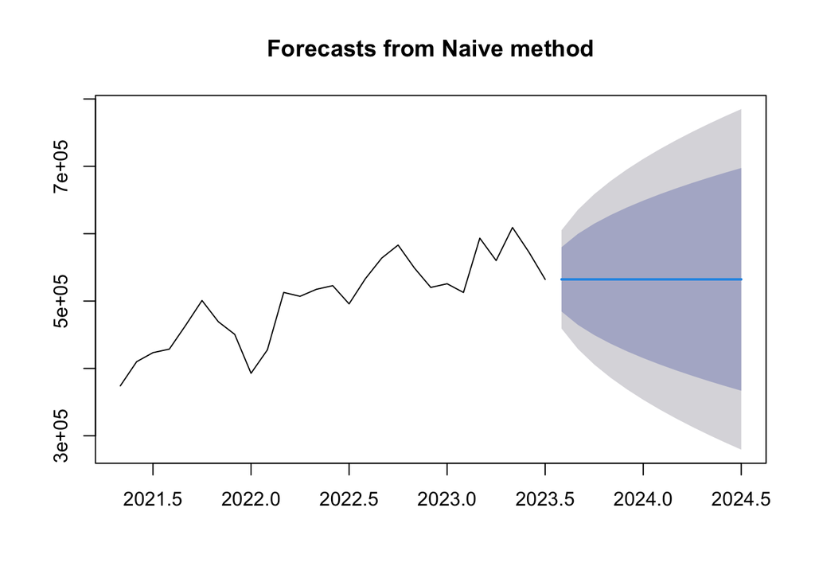

```r
plot(naive_forecast)
```

#### This model simply uses the last observed value of the time series as the forecast for the future periods.

- The shaded region represents the forecast intervals, showing increasing uncertainty over time.

#### 3.2 Simple Moving Averages

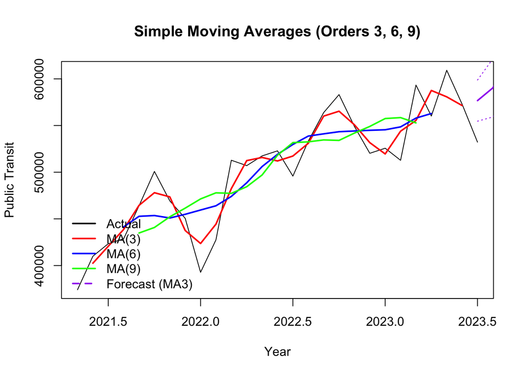

```r
# Compute moving averages of different orders
MA3_forecast <- ma(Transit_ts, order = 3)
MA6_forecast <- ma(Transit_ts, order = 6)
MA9_forecast <- ma(Transit_ts, order = 9)

# Plot original time series
plot(Transit_ts, main = "Simple Moving Averages (Orders 3, 6, 9)",
     ylab = "Public Transit", xlab = "Year", col = "black")

# Add the three moving averages
lines(MA3_forecast, col = "red", lwd = 2)
lines(MA6_forecast, col = "blue", lwd = 2)
lines(MA9_forecast, col = "green", lwd = 2)

# Forecast next 12 month using order 6
fit_ma6 <- auto.arima(na.omit(MA3_forecast))
forecast_ma3 <- forecast(fit_ma6, h = 12)
lines(forecast_ma3$mean, col = "purple", lwd = 2)

# Optionally add confidence intervals
lines(forecast_ma3$lower[,2], col = "purple", lty = 3)
lines(forecast_ma3$upper[,2], col = "purple", lty = 3)

# Add a legend
legend("bottomleft",
       legend = c("Actual", "MA(3)", "MA(6)", "MA(9)", "Forecast (MA3)"),
       col = c("black", "red", "blue", "green", "purple"),
       lty = c(1, 1, 1, 1, 2),
       lwd = 2,
       bty = "n")
```

##### As the moving average order increases, the time series becomes progressively smoother.

- MA(3) closely follows the actual data while slightly reducing short-term fluctuations, effectively retaining most of the seasonal pattern.
- MA(6) provides moderate smoothing, filtering out more noise but beginning to weaken the seasonal variations.
- MA(9) yields the smoothest curve, capturing the overall trend but largely removing seasonal detail.

#### Therefore, MA(3) is selected for forecasting because it provides a good balance between noise reduction and the preservation of important seasonal signals in public transit ridership.

### 3.3 Simple Smoothing

```r
ss_forecast <- ses(Transit_ts, h = 12)
ss_forecast$model
```

```
## Simple exponential smoothing
##
## Call:
## ses(y = Transit_ts, h = 12)
##
##   Smoothing parameters:
##     alpha = 0.9273
##
##   Initial states:
##     l = 376776.1973
##
##   sigma:  37902.97
##
##      AIC     AICc      BIC
## 662.2200 663.2635 666.1075
```

#### Model Parameters

- **Alpha (α) = 0.9273**
  - The smoothing parameter is very high (close to 1), meaning the model gives much more weight to recent observations and quickly adapts to recent changes.
  - This suggests that the data may change rapidly or have short-term fluctuations.
- **Initial State (l₀) = 376776.1973**
  - This represents the model’s *starting level* estimate at the beginning of the time series.
  - It acts as the baseline from which the exponential smoothing process begins.
- **Sigma (σ) = 37902.97**
  - Measures the standard deviation of forecast errors, reflecting the average variability in residuals.
  - The smaller the sigma, the more consistent and accurate the model fit; a higher sigma indicates higher variability and uncertainty.

#### 3.3.1 Residuals

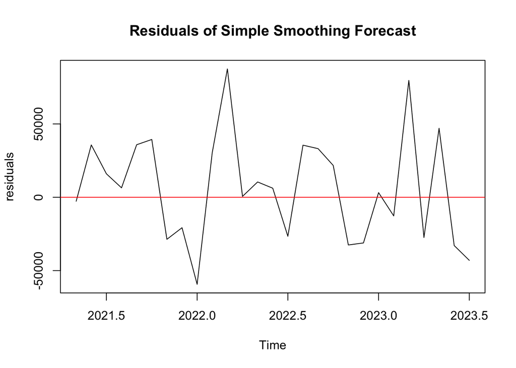

```r
ss_residual <- residuals(ss_forecast)

# plot the residuals
plot(ss_residual, main = "Residuals of Simple Smoothing Forecast", ylab = "residuals")
abline(h=0, col="red")
```

> The residuals fluctuate around zero, indicating no systematic bias in the model. However, the repeating peaks and troughs suggest that some seasonal pattern remains in the residuals — meaning the Simple Exponential Smoothing model has not captured the seasonality in the data.

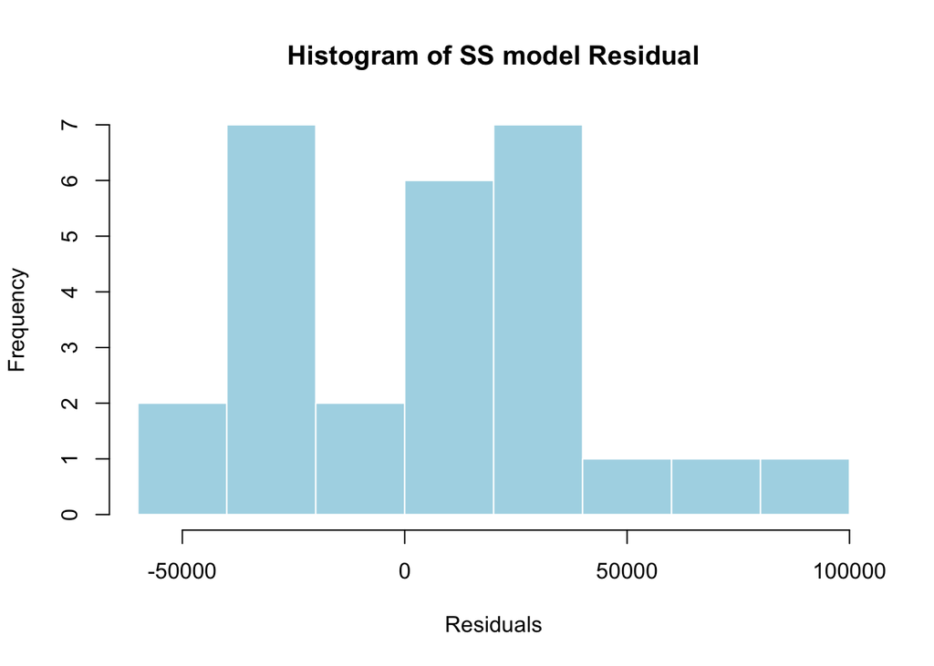

```r
# histogram
hist(ss_residual, main = "Histogram of SS model Residual", xlab="Residuals", col="lightblue", border="white")
```

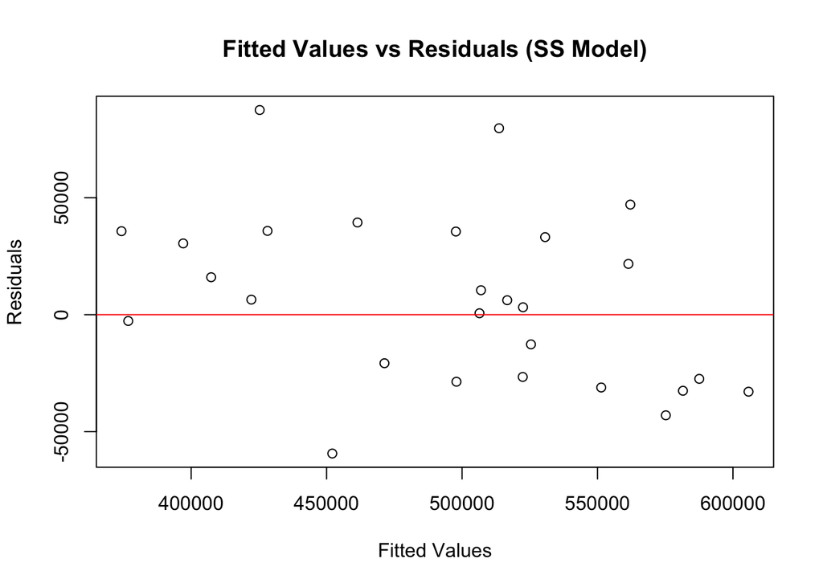

```r
# Plot fitted vs residuals
plot(as.numeric(ss_forecast$fitted), as.numeric(ss_forecast$residuals),
     main="Fitted Values vs Residuals (SS Model)",
     xlab="Fitted Values", ylab="Residuals")
abline(h=0, col="red")
```

> The residuals are randomly scattered around zero, indicating no systematic bias, but larger deviations at some fitted values suggest the model underestimates variability in some periods.

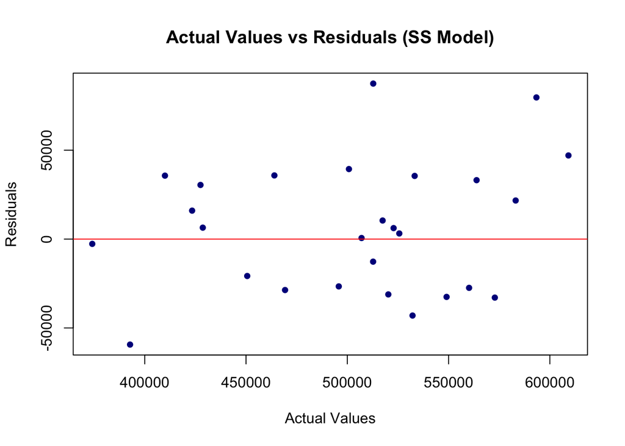

```r
# Plot real time vs residuals
plot(as.numeric(Transit_ts), as.numeric(ss_forecast$residuals),
     main = "Actual Values vs Residuals (SS Model)",
     xlab = "Actual Values", ylab = "Residuals",
     type = "p", pch = 19, col = "darkblue", cex= 0.8)
abline(h = 0, col = "red")
```

> Residuals are centered around zero but show greater variability at higher actual values, suggesting underfitting during high-demand periods.

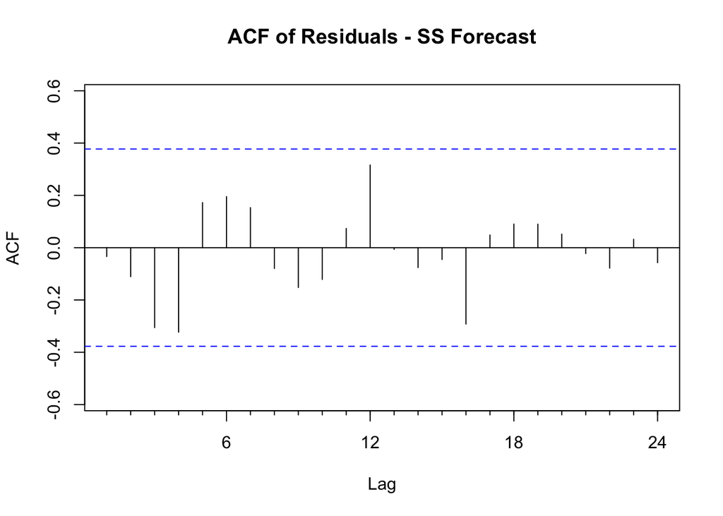

```r
# Plot residuals acf
Acf(ss_residual, main="ACF of Residuals - SS Forecast")
```

#### 3.3.2 Accuracy & Forecast plot

```r
accuracy(ss_forecast)
```

```
##                    ME     RMSE      MAE      MPE     MAPE      MASE        ACF1
## Training set 6332.991 36472.15 29877.77 1.113625 5.931206 0.3461395 -0.03393331
```

```r
ss_forecast
```

```
##          Point Forecast    Lo 80    Hi 80    Lo 95    Hi 95
## Aug 2023       535334.1 486759.5 583908.8 461045.7 609622.6
## Sep 2023       535334.1 469089.6 601578.7 434021.9 636646.4
## Oct 2023       535334.1 455226.8 615441.5 412820.5 657847.8
## Nov 2023       535334.1 443431.8 627236.4 394781.7 675886.6
## Dec 2023       535334.1 432987.3 637681.0 378808.1 691860.2
## Jan 2024       535334.1 423514.1 647154.2 364320.1 706348.2
## Feb 2024       535334.1 414783.0 655885.3 350967.1 719701.2
## Mar 2024       535334.1 406643.0 664025.3 338518.0 732150.3
## Apr 2024       535334.1 398988.0 671680.3 326810.7 743857.6
## May 2024       535334.1 391740.6 678927.7 315726.7 754941.6
## Jun 2024       535334.1 384841.8 685826.5 305175.9 765492.4
## Jul 2024       535334.1 378245.6 692422.7 295088.0 775580.3
```

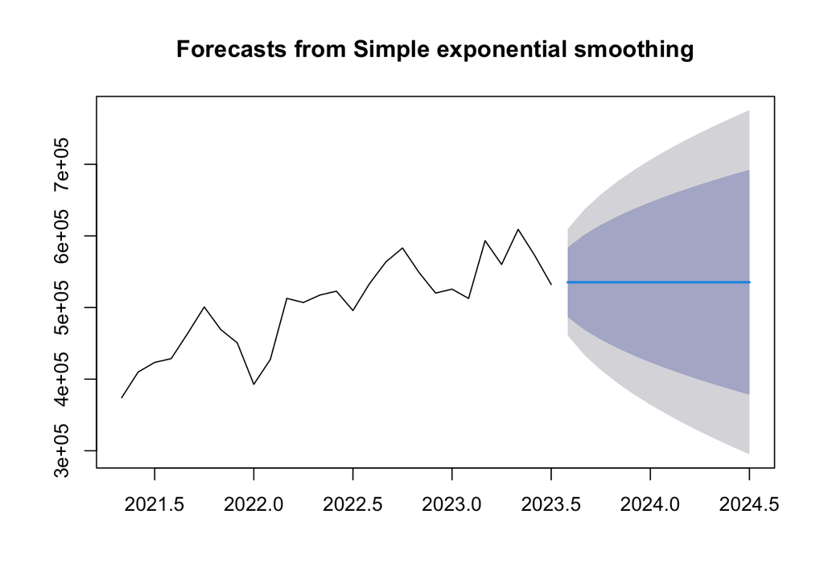

```r
plot(ss_forecast)
```

##### This flat forecast reflects the model’s level-only nature — SES does not capture trend or seasonality, so it assumes future values will stay close to the recent average level.

> According to the forecast table, the predicted ridership remains constant at around 535,334 for all future months. The SES (Simple Exponential Smoothing) model has - RMSE = 36,472.15 - MAE = 29,877.77 - MAPE = 5.93% - MASE = 0.35

### 3.4 Holt-Winter

```r
transit_hw <- hw(Transit_ts)
forecast_hw <- forecast(transit_hw, h = 12)
transit_hw$model
```

```
## Holt-Winters' additive method
##
## Call:
## hw(y = Transit_ts)
##
##   Smoothing parameters:
##     alpha = 1e-04
##     beta  = 1e-04
##     gamma = 0.4562
##
##   Initial states:
##     l = 404976.4613
##     b = 7050.2461
##     s = 19513.93 32325.15 -45905.61 -73543.36 -8732.157 16998
##            55579.26 25829.47 -2471.354 -689.1707 -7048.893 -11855.27
##
##   sigma:  33394.99
##
##      AIC     AICc      BIC
## 661.2159 729.2159 683.2451
```

> The Holt-Winters additive model captures a mild upward trend and moderate seasonality, but with nearly zero α and β, it updates very slowly, relying mostly on the initial state rather than recent data.

#### 3.4.1 Residual Analysis

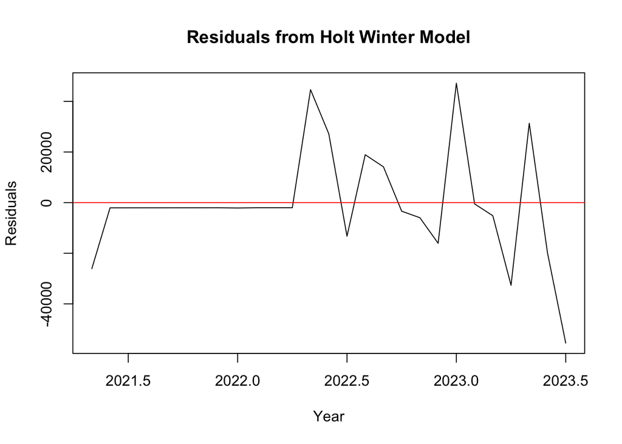

```r
hw_residual = residuals(forecast_hw)

#plot residuals
plot(hw_residual, main = "Residuals from Holt Winter Model", ylab="Residuals", xlab = "Year")
abline(h=0, col="red")
```

> During the early part of the time series (around 2021 to early 2022), the residuals stay close to zero with relatively small fluctuations, indicating that the model fitted the data well during this stable period. However, starting from around March 2022, the residuals exhibit several large peaks and troughs, showing greater volatility and alternating positive/negative deviations.

> The model fits well in early periods but fails to track the increased volatility after 2022, indicating limited adaptability to changing seasonal dynamics.

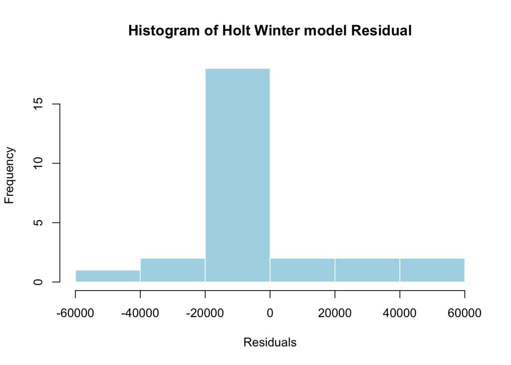

```r
#histogram
hist(hw_residual, main = "Histogram of Holt Winter model Residual", xlab="Residuals", col="lightblue", border="white")
```

> The residuals are centered near zero with a roughly symmetric distribution, showing that the Holt-Winters model fits the data reasonably well without major bias.

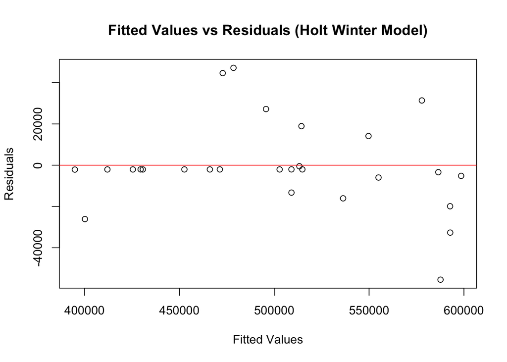

```r
# fitted value vs residuals
plot(as.numeric(fitted(forecast_hw)), as.numeric(hw_residual),
     main="Fitted Values vs Residuals (Holt Winter Model)",
     xlab="Fitted Values", ylab="Residuals")
abline(h=0, col="red")
```

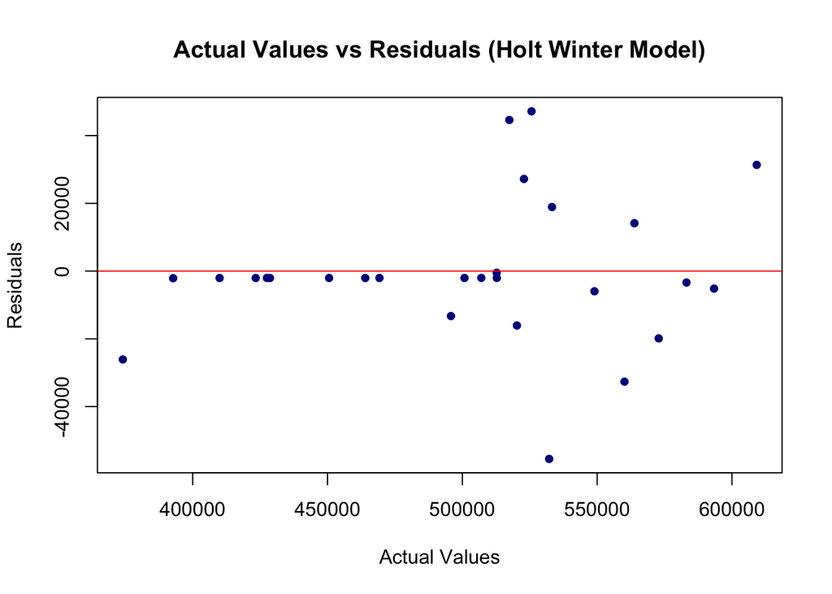

```r
# real values vs residuals
plot(as.numeric(Transit_ts), as.numeric(hw_residual),
     main = "Actual Values vs Residuals (Holt Winter Model)",
     xlab = "Actual Values", ylab = "Residuals",
     type = "p", pch = 19, col = "darkblue", cex= 0.8)
abline(h = 0, col = "red")
```

> Most residuals stay near zero, showing good model fit, but a few large positive residuals at high actual values suggest minor underestimation during peak periods.

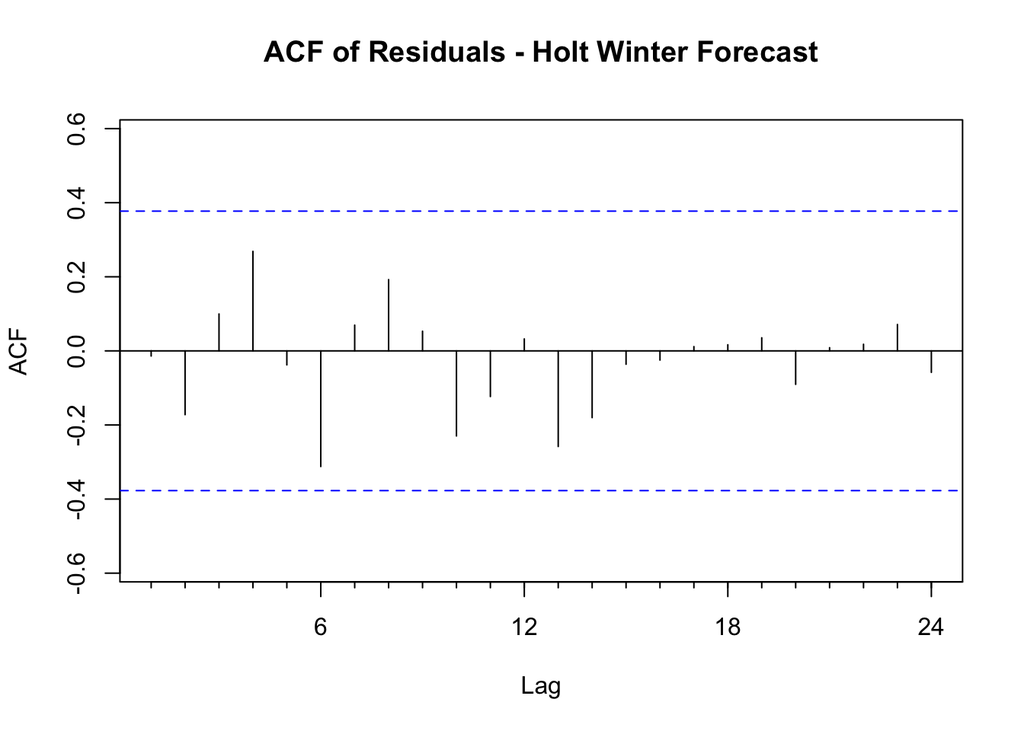

```r
#ACF plot of residuals
Acf(hw_residual, main="ACF of Residuals - Holt Winter Forecast")
```

> The residuals show no significant autocorrelation, suggesting that the Holt-Winters model has effectively captured the systematic structure in the series.

#### 3.4.2 Accuracy & forecast plot

```r
accuracy(forecast_hw)
```

```
##                     ME     RMSE     MAE        MPE     MAPE      MASE
## Training set -648.3692 21315.51 14233.5 -0.2256338 2.744208 0.1648978
##                     ACF1
## Training set -0.01394573
```

```r
forecast_hw
```

```
##          Point Forecast    Lo 80    Hi 80    Lo 95    Hi 95
## Aug 2023       607611.7 564814.3 650409.1 542158.7 673064.7
## Sep 2023       640777.9 597980.5 683575.3 575324.9 706230.8
## Oct 2023       669589.8 626792.4 712387.2 604136.8 735042.8
## Nov 2023       636878.6 594081.2 679676.0 571425.6 702331.6
## Dec 2023       613595.3 570797.9 656392.7 548142.3 679048.3
## Jan 2024       584636.6 541839.2 627434.1 519183.6 650089.6
## Feb 2024       597618.6 554821.2 640416.1 532165.6 663071.7
## Mar 2024       680770.4 637973.0 723567.9 615317.4 746223.5
## Apr 2024       662474.9 619677.4 705272.3 597021.8 727927.9
## May 2024       676717.9 633920.4 719515.4 611264.8 742171.0
## Jun 2024       668226.3 625428.8 711023.8 602773.2 733679.5
## Jul 2024       646940.6 604143.0 689738.1 581487.4 712393.8
```

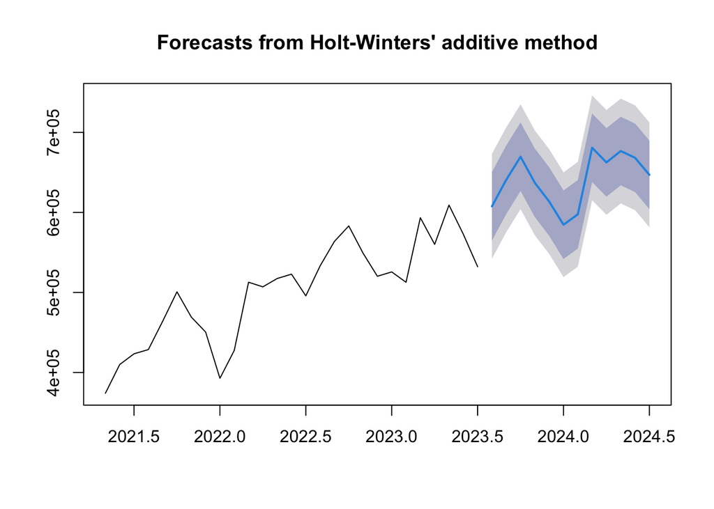

```r
plot(forecast_hw)
```

> This indicates that the model fits the data well and provides reliable short-term forecasts, as the residuals behave approximately like white noise.

> The forecast for Jul 2024 (one year ahead) is approximately 646,940 passengers, with an 80% confidence interval between 604,000 and 690,000.

## 3.5 Accuracy summary

```r
# Create accuracy comparison table
model_comparison <- rbind(
  naive = accuracy(naive_forecast),
  ss = accuracy(ss_forecast),
  ma = accuracy(forecast_ma3),
  hw = accuracy(forecast_hw)
)

rownames(model_comparison) <- c( "Naive",  "SS", "Moving Average","Holt Winter")
round(model_comparison[, c("RMSE","MAE","MAPE","MASE")], 3)
```

```
##                     RMSE       MAE  MAPE  MASE
## Naive          37238.927 31228.346 6.182 0.362
## SS             36472.146 29877.767 5.931 0.346
## Moving Average  7789.591  4321.351 0.790 0.050
## Holt Winter    21315.513 14233.501 2.744 0.165
```

Best and Worst Forecast Methods (Based on RMSE) - Best: **Moving Average** (RMSE = 7,789.591) This model achieved the lowest RMSE, indicating it provides the most accurate and stable forecasts among all tested models. - Worst: **Naïve** (RMSE = 37,238.927) The Naïve model performed worst because it simply repeats the last observed value and fails to capture underlying trends or seasonal variations.